# Analitica sl2l_mean_length

### Conclusiones del Análisis sl2l_mean_length

Buscamos en el feature sl2l_mean_length un estimador de posición y establecer su distribución.

Estos pasos siguientes fueron realizados a partir de exploración gráfica de los datos y bajo conocimiento de su captura y procesamiento.

**Paso 1**: separar valores en control y estudio.  
**Paso 2:** verificar valores repetidos.En este caso no existen repetidos.  
**Paso 3:** Limpiar los outliers, de manera general cuando existe cuando se juntan ambas particiones.

Luego, verificando y ajustando a distribuciones teóricas, se asemeja a la distribución normal. Realizamos los ajustes, aunque sus datos no logran ajustar del todo.  
También, realizamos pruebas con distribución libre o sin Ajuste total a una distribución teórica, utilizamos diferentes nucleos y ancho de banda.

Con prechequeo formal formal de normalidad (**shapiro-wilk y Anderson-Darling)**, sostiene la hipótesis de normalidad.

Por otro lado, es importante analizar las distribuciones separadas entre Control y Estudio en este features para verificar sus diferencias.

Entonces, nuevamente es importante ajustar la distribución lo mejor posible a su promedio, para lograr diferenciar y llegar a la verdadera posición central. (ver la necesidad del tamaño de muestra ante el uso del sistema libre distribucion)

Podemos pensar en una distribución teorica normal y pensar en Silverman para establecer la posición y sus desviaciones ajustadas.

```r
library(ggplot2)
library(gridExtra)
library(MASS)
library(fitdistrplus)
library(ggstatsplot)
library(BSSasymp) #Cramer-ca
```

```r
### Ubicacion de datos
setwd("C:/hcgalvan/Repositorios/hcgalvan_project/data/union/End")
temp = gsub(".*target.*", "", readLines("seleccionestudio.csv"))
data<-read.table(text=temp, sep=",", header=TRUE)
sl2lml <-data$sl2l_mean_length
```

#### Tratamiento Ajustado a Distribución y comparativa con/sin outliers

Separamos los datos de la variable de estudio

```r
Control<-(as.numeric(unlist(subset(data, label==1, select=c(sl2l_mean_length)))))
Estudio<-(as.numeric(unlist(subset(data, label==0, select=c(sl2l_mean_length)))))
Controlclean<-unique(Control)
Estudioclean<-unique(Estudio)
```

```
[1] 95.7897 95.7897
```

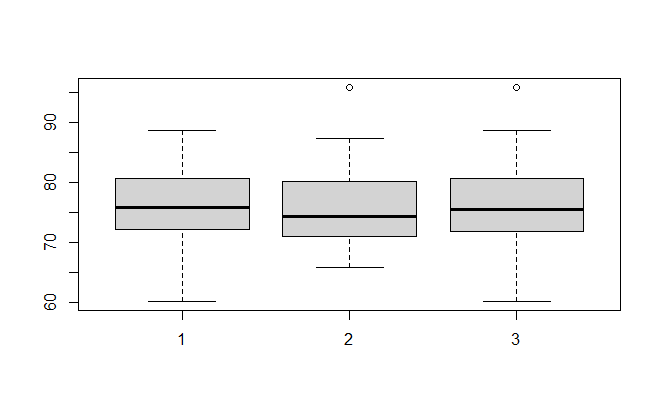

```r
boxplot(Control, Estudio, sl2lml)$out
```

```r
Q <- quantile(data$sl2l_mean_length, probs=c(.25, .75), na.rm = FALSE)
iqr <- IQR(data$sl2l_mean_length)
up <-  Q[2]+1.5*iqr # Upper Range
low<- Q[1]-1.5*iqr # Lower Range
datasinout<- subset(data, data$sl2l_mean_length > (Q[1] - 1.5*iqr) & data$sl2l_mean_length < (Q[2]+1.5*iqr))
```

[output not shown]

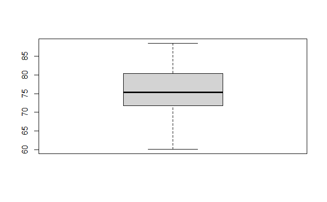

```r
boxplot(datasinout$sl2l_mean_length)$out
```

Graficamos las distribuciones obtenidos.

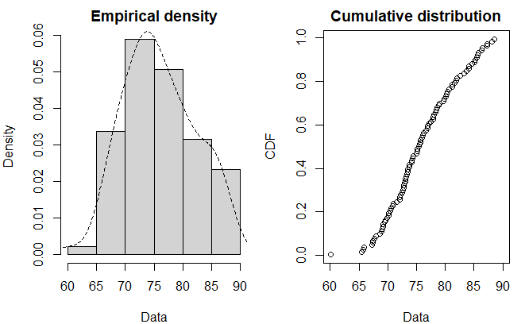

```r
par(mfrow = c(2, 2), mar = c(4, 4, 2, 1))
plotdist(datasinout$sl2l_mean_length, histo=TRUE, demp=TRUE) #completamente ajustado
```

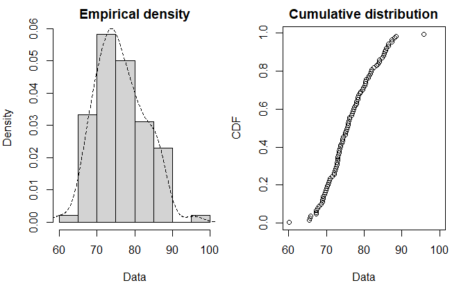

```r
plotdist(data$sl2l_mean_length, histo=TRUE, demp=TRUE) #completamente ajustado
```

```r
summary(datasinout$sl2l_mean_length)
```

```
   Min. 1st Qu.  Median    Mean 3rd Qu.    Max.
  60.09   71.83   75.34   75.98   80.37   88.53
```

```r
summary(data$sl2l_mean_length)
```

```
   Min. 1st Qu.  Median    Mean 3rd Qu.    Max.
  60.09   71.95   75.42   76.18   80.49   95.79
```

```
summary statistics
------
min:  60.0889   max:  88.5339
median:  75.3438
mean:  75.97592
estimated sd:  6.164165
estimated skewness:  0.1464628
estimated kurtosis:  2.428384
```

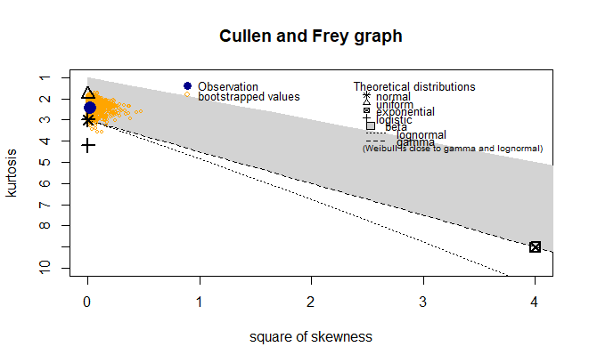

```r
descdist(datasinout$sl2l_mean_length, boot = 1000)
```

```
summary statistics
------
min:  60.0889   max:  95.7897
median:  75.41825
mean:  76.18232
estimated sd:  6.456501
estimated skewness:  0.3388031
estimated kurtosis:  2.921261
```

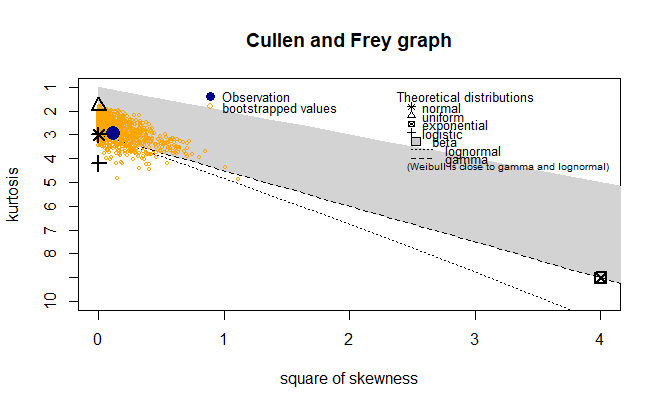

```r
descdist(data$sl2l_mean_length, boot = 1000)
```

Ajustamos los datos a la distribución Normal

```r
library(glogis)
total<-fitdist(datasinout$sl2l_mean_length, "norm")
sinajuste<-fitdist(data$sl2l_mean_length, "norm")
summary(total)
```

```
Fitting of the distribution ' norm ' by maximum likelihood
Parameters :
```

|  | estimate | Std. Error |
| --- | --- | --- |
| mean | 75.975922 | 0.6290926 |
| sd | 6.131636 | 0.4448356 |

```
Loglikelihood:  -307.078   AIC:  618.156   BIC:  623.2638
Correlation matrix:
     mean sd
mean    1  0
sd      0  1
```

```r
summary(sinajuste)
```

```
Fitting of the distribution ' norm ' by maximum likelihood
Parameters :
```

|  | estimate | Std. Error |
| --- | --- | --- |
| mean | 76.182316 | 0.6555228 |
| sd | 6.422785 | 0.4635245 |

```
Loglikelihood:  -314.7639   AIC:  633.5277   BIC:  638.6564
Correlation matrix:
     mean sd
mean    1  0
sd      0  1
```

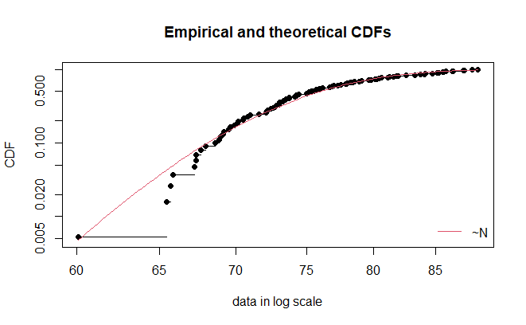

```r
library(actuar)
ATV1 <- datasinout$sl2l_mean_length
datos1.l<-fitdist(ATV1, "norm")
cdfcomp(list(datos1.l), xlogscale = TRUE,
        ylogscale = TRUE, legendtext = c("~N"))
```

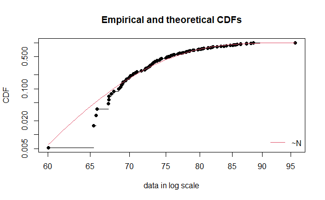

```r
ATV <- data$sl2l_mean_length
datos.l<-fitdist(ATV, "norm")
cdfcomp(list(datos.l), xlogscale = TRUE,
        ylogscale = TRUE, legendtext = c("~N"))
```

### Test formal de normalidad.

```r
library(EnvStats)
library(nortest)
shapiro.test(datasinout$sl2l_mean_length)
```

```
    Shapiro-Wilk normality test

data:  datasinout$sl2l_mean_length
W = 0.98073, p-value = 0.1754
```

```r
ad.test(datasinout$sl2l_mean_length) #prueba de normalidad de Anderson-Darling
```

```
    Anderson-Darling normality test

data:  datasinout$sl2l_mean_length
A = 0.53437, p-value = 0.1673
```

```r
shapiro.test(data$sl2l_mean_length)
```

```
    Shapiro-Wilk normality test

data:  data$sl2l_mean_length
W = 0.98409, p-value = 0.2987
```

```r
ad.test(data$sl2l_mean_length) #prueba de normalidad de Anderson-Darling
```

```
    Anderson-Darling normality test

data:  data$sl2l_mean_length
A = 0.52512, p-value = 0.1766
```

### Analítica NO PARAMÉTRICA; libre distribución

```r
bw.nrd0(datasinout$sl2l_mean_length) #regla general de Silverman
```

```
[1] 2.231372
```

```r
bw.nrd(datasinout$sl2l_mean_length)  #regla general de Scott
```

```
[1] 2.628061
```

```r
bw.bcv(datasinout$sl2l_mean_length)  #convalidación cruzada
```

```
[1] 2.823456
```

```r
bw.ucv(datasinout$sl2l_mean_length)  #validación cruzada imparcial
```

```
[1] 2.822611
```

```r
bw.SJ(datasinout$sl2l_mean_length)   #Sheather & método Jones
```

```
[1] 2.603655
```

```r
density.default(x = datasinout$sl2l_mean_length, kernel = "gaussian")
```

```
Call:
    density.default(x = datasinout$sl2l_mean_length, kernel = "gaussian")

Data: datasinout$sl2l_mean_length (95 obs.);    Bandwidth 'bw' = 2.231

       x               y
 Min.   :53.39   Min.   :0.0000212
 1st Qu.:63.85   1st Qu.:0.0022364
 Median :74.31   Median :0.0218625
 Mean   :74.31   Mean   :0.0238802
 3rd Qu.:84.77   3rd Qu.:0.0422024
 Max.   :95.23   Max.   :0.0610243
```

```r
density.default(x = datasinout$sl2l_mean_length, kernel = "epanechnikov")
```

```
Call:
    density.default(x = datasinout$sl2l_mean_length, kernel = "epanechnikov")

Data: datasinout$sl2l_mean_length (95 obs.);    Bandwidth 'bw' = 2.231

       x               y
 Min.   :53.39   Min.   :0.000000
 1st Qu.:63.85   1st Qu.:0.001698
 Median :74.31   Median :0.021492
 Mean   :74.31   Mean   :0.023881
 3rd Qu.:84.77   3rd Qu.:0.041949
 Max.   :95.23   Max.   :0.059811
```

```r
density.default(x = datasinout$sl2l_mean_length, bw="nrd", kernel = "gaussian")
```

```
Call:
    density.default(x = datasinout$sl2l_mean_length, bw = "nrd",     kernel = "gaussian")

Data: datasinout$sl2l_mean_length (95 obs.);    Bandwidth 'bw' = 2.628

       x               y
 Min.   :52.20   Min.   :1.797e-05
 1st Qu.:63.26   1st Qu.:1.855e-03
 Median :74.31   Median :1.847e-02
 Mean   :74.31   Mean   :2.259e-02
 3rd Qu.:85.36   3rd Qu.:4.079e-02
 Max.   :96.42   Max.   :5.901e-02
```

```r
density.default(x = datasinout$sl2l_mean_length, bw="SJ", kernel = "gaussian")
```

```
Call:
    density.default(x = datasinout$sl2l_mean_length, bw = "SJ", kernel = "gaussian")

Data: datasinout$sl2l_mean_length (95 obs.);    Bandwidth 'bw' = 2.604

       x               y
 Min.   :52.28   Min.   :1.813e-05
 1st Qu.:63.29   1st Qu.:1.878e-03
 Median :74.31   Median :1.865e-02
 Mean   :74.31   Mean   :2.267e-02
 3rd Qu.:85.33   3rd Qu.:4.085e-02
 Max.   :96.34   Max.   :5.913e-02
```

```r
density.default(x = datasinout$sl2l_mean_length, bw="bcv", kernel = "gaussian")
```

```
Call:
    density.default(x = datasinout$sl2l_mean_length, bw = "bcv",     kernel = "gaussian")

Data: datasinout$sl2l_mean_length (95 obs.);    Bandwidth 'bw' = 2.823

       x               y
 Min.   :51.62   Min.   :1.674e-05
 1st Qu.:62.96   1st Qu.:1.700e-03
 Median :74.31   Median :1.711e-02
 Mean   :74.31   Mean   :2.201e-02
 3rd Qu.:85.66   3rd Qu.:4.017e-02
 Max.   :97.00   Max.   :5.809e-02
```

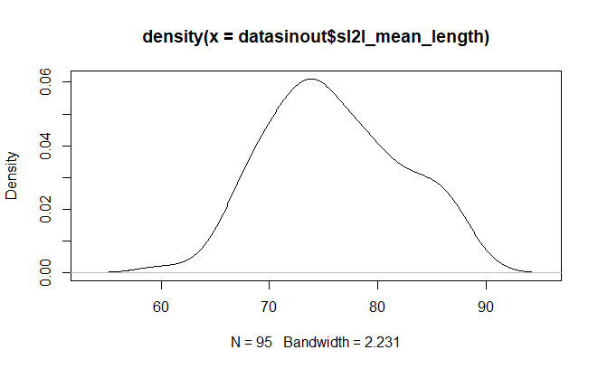

```r
require(graphics)

plot(density(datasinout$sl2l_mean_length))  # IQR = 0
```

```r
# The Old Faithful geyser data
d <- density(datasinout$sl2l_mean_length, bw = "sj")
d
```

```
Call:
    density.default(x = datasinout$sl2l_mean_length, bw = "sj")

Data: datasinout$sl2l_mean_length (95 obs.);    Bandwidth 'bw' = 2.604

       x               y
 Min.   :52.28   Min.   :1.813e-05
 1st Qu.:63.29   1st Qu.:1.878e-03
 Median :74.31   Median :1.865e-02
 Mean   :74.31   Mean   :2.267e-02
 3rd Qu.:85.33   3rd Qu.:4.085e-02
 Max.   :96.34   Max.   :5.913e-02
```

```r
plot(d)

## Missing values:
x <- xx <- datasinout$sl2l_mean_length
x[i.out <- sample(length(x), 10)] <- NA
doR <- density(x, bw = 1550.821, na.rm = TRUE)
lines(doR, col = "blue")
```

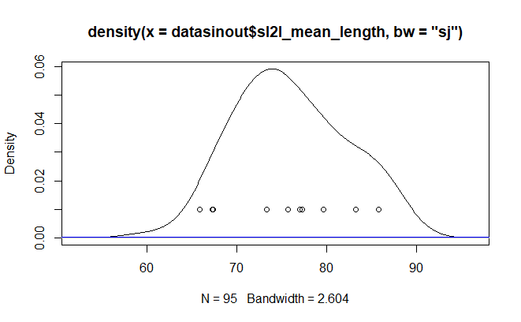

```r
points(xx[i.out], rep(0.01, 10))
```

```r
## Weighted observations:
fe <- sort(datasinout$sl2l_mean_length) # has quite a few non-unique values
## use 'counts / n' as weights:
dw <- density(unique(fe), weights = table(fe)/length(fe), bw = d$bw)
utils::str(dw) ## smaller n: only 126, but identical estimate:
```

```
List of 7
 $ x        : num [1:512] 52.3 52.4 52.5 52.5 52.6 ...
 $ y        : num [1:512] 1.81e-05 2.00e-05 2.21e-05 2.43e-05 2.68e-05 ...
 $ bw       : num 2.6
 $ n        : int 95
 $ call     : language density.default(x = unique(fe), bw = d$bw, weights = table(fe)/length(fe))
 $ data.name: chr "unique(fe)"
 $ has.na   : logi FALSE
 - attr(*, "class")= chr "density"
```

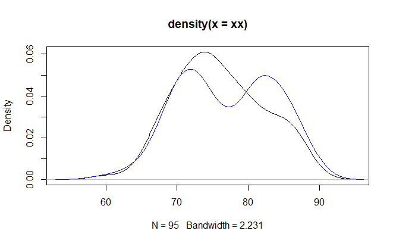

```r
stopifnot(all.equal(d[1:3], dw[1:3]))

## simulation from a density() fit:
# a kernel density fit is an equally-weighted mixture.
fit <- density(xx)
N <- length(datasinout$sl2l_mean_length)
x.new <- rnorm(N, sample(xx, size = N, replace = TRUE), fit$bw)
plot(fit)
lines(density(x.new), col = "blue")
```

```r
(kernels <- eval(formals(density.default)$kernel))
```

```
[1] "gaussian"     "epanechnikov" "rectangular"  "triangular"   "biweight"     "cosine"       "optcosine"
```

```r
##-------- Semi-advanced theoretic from here on -------------
## <!-- %% i.e. "secondary example" in a new help system ... -->
(RKs <- cbind(sapply(kernels,
                     function(k) density(kernel = k, give.Rkern = TRUE))))
```

```
                  [,1]
gaussian     0.2820948
epanechnikov 0.2683282
rectangular  0.2886751
triangular   0.2721655
biweight     0.2699746
cosine       0.2711340
optcosine    0.2684756
```

```r
100*round(RKs["epanechnikov",]/RKs, 4) ## Efficiencies
```

```
               [,1]
gaussian      95.12
epanechnikov 100.00
rectangular   92.95
triangular    98.59
biweight      99.39
cosine        98.97
optcosine     99.95
```

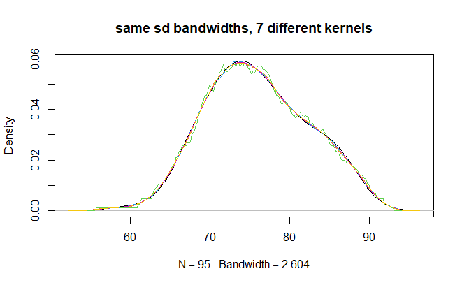

```r
bw <- bw.SJ(datasinout$sl2l_mean_length) ## sensible automatic choice
plot(density(datasinout$sl2l_mean_length, bw = bw),
     main = "same sd bandwidths, 7 different kernels")
for(i in 2:length(kernels))
   lines(density(datasinout$sl2l_mean_length, bw = bw, kernel = kernels[i]), col = i)
```

```r
## Bandwidth Adjustment for "Exactly Equivalent Kernels"
h.f <- sapply(kernels, function(k)density(kernel = k, give.Rkern = TRUE))
(h.f <- (h.f["gaussian"] / h.f)^ .2)
```

```
    gaussian epanechnikov  rectangular   triangular     biweight       cosine    optcosine
   1.0000000    1.0100567    0.9953989    1.0071923    1.0088217    1.0079575    1.0099458
```

```r
## -> 1, 1.01, .995, 1.007,... close to 1 => adjustment barely visible..

plot(density(datasinout$sl2l_mean_length, bw = bw),
     main = "equivalent bandwidths, 7 different kernels")
for(i in 2:length(kernels))
   lines(density(datasinout$sl2l_mean_length, bw = bw, adjust = h.f[i], kernel = kernels[i]),
         col = i)
```

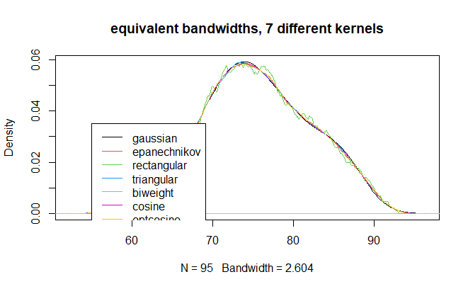

```r
legend(55, 0.035, legend = kernels, col = seq(kernels), lty = 1)
```